# Assessing patient-reported outcomes, pharmacist interventions and medication adherence in Multiple Sclerosis

Ryan Moore

Leena Choi

Department of Biostatistics

Vanderbilt University Medical Center

2022-09-12

# 1 Study Details

## 1.1 Background

Patient reported outcomes (PROs), defined as a measurement of any aspect of a patient’s health status that comes directly from the patient, are an effective took for understanding patient insights into their disease management, quality of life and functioning and can help inform clinical decision making and improve quality of care. VSP’s current workflow captures specific PROs during monthly refill assessments and alerts the pharmacist of any negative findings. An integrated clinic pharmacist then performs a variety of interventions to facilitate medication adherence and identify medication safety or effectiveness or further coordination of care.

## 1.2 Objectives

- Quantify patient-reported response to therapy
- Quantify number and type of pharmacist interventions performed during monthly refill assessments.

## 1.3 Inclusion Criteria

- Patients must have at least 2 medications fills through VSP
- Patients must have at least 2 MRQ responses
- Medication fills must have occurred between January and March 2020 `
- Medication must be prescribed by a VUMC multiple sclerosis clinic provider

# 2 Descriptive statistics

## 2.1 Demographics and patient characteristics

There are 335 unique patients that completed 1017 MRQs.

| Baseline Descriptive Statistics, Diagnosis, and Medication. | Baseline Descriptive Statistics, Diagnosis, and Medication. *N=335* |
| --- | --- |
| Age | 45.0 52.3 59.9 |
| Gender |  |
| Female | 0.76 (256) |
| Male | 0.24 ( 79) |
| Race |  |
| White | 0.82 (274) |
| Black or African American | 0.15 ( 50) |
| American Indian or Alaska Native | 0.00 ( 1) |
| Other Asian | 0.00 ( 1) |
| Unknown | 0.03 ( 9) |
| Ethnicity |  |
| Not Hispanic, Latino/a, or Spanish origin | 0.95 (319) |
| Unknown | 0.04 ( 12) |
| Other Hispanic, Latino/a, or Spanish origin | 0.01 ( 4) |
| Insurance Type |  |
| Commercial | 0.59 (196) |
| Medicare | 0.38 (127) |
| Medicaid | 0.04 ( 12) |
| Speciality Med |  |
| Ampyra/XR (dalfampridine) | 0.10 (33) |
| Aubagio (teriflunomide) | 0.10 (32) |
| Gilenya (fingolimod) | 0.22 (74) |
| glatiramer acetate | 0.17 (56) |
| interferon beta-1a | 0.17 (56) |
| interferon beta-1b | 0.04 (13) |
| Mayzent (siponimod) | 0.00 ( 1) |
| Plegridy (peginterferon beta-1a) | 0.02 ( 7) |
| Tecfidera (dimethyl fumarate) | 0.19 (63) |
| MS Indication |  |
| Relapsing-remitting | 0.88 (295) |
| Primary progressive | 0.03 ( 11) |
| Secondary progressive | 0.08 ( 27) |
| Tumefactive | 0.00 ( 1) |
| Clinically isolated syndrome | 0.00 ( 1) |

*a* *b* *c* represent the lower quartile *a*, the median *b*, and the upper quartile *c* for continuous variables. Numbers after proportions are frequencies.

### 2.1.1 Specialty medication by Indication

Medication by Indication

|  | Relapsing-remitting | Primary progressive | Secondary progressive | Tumefactive | Clinically isolated syndrome |
| --- | --- | --- | --- | --- | --- |
| Ampyra/XR (dalfampridine) | 13 | 8 | 12 | 0 | 0 |
| Aubagio (teriflunomide) | 27 | 0 | 4 | 1 | 0 |
| Gilenya (fingolimod) | 71 | 1 | 2 | 0 | 0 |
| glatiramer acetate | 53 | 0 | 3 | 0 | 0 |
| interferon beta-1a | 54 | 0 | 1 | 0 | 1 |
| interferon beta-1b | 12 | 0 | 1 | 0 | 0 |
| Mayzent (siponimod) | 0 | 1 | 0 | 0 | 0 |
| Plegridy (peginterferon beta-1a) | 7 | 0 | 0 | 0 | 0 |
| Tecfidera (dimethyl fumarate) | 58 | 1 | 4 | 0 | 0 |

# 3 MRQ

## 3.1 Count of MRQs per patient

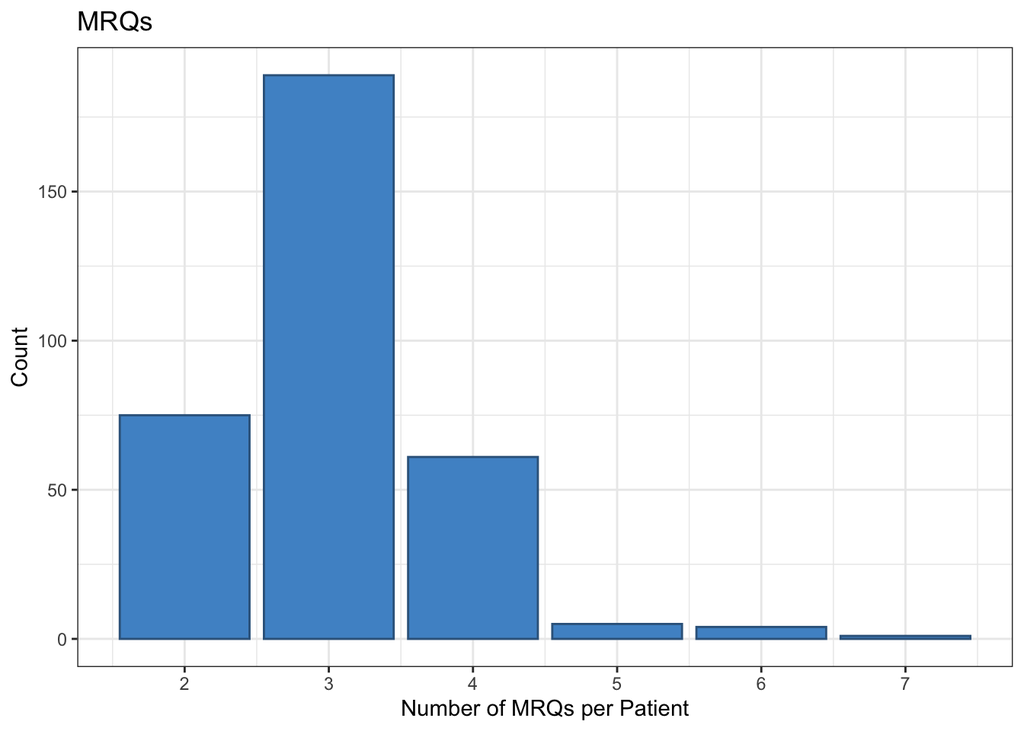

## 3.2 Missed doses

### 3.2.1 Missed Doses Per Patient

| Descriptive Statistics *(N=335)*. | Descriptive Statistics *(N=335)*. *N=335* |
| --- | --- |
| Number of Missed Doses |  |
| 0 | 0.90 (301) |
| 1 | 0.09 ( 31) |
| 2 | 0.01 ( 3) |

Numbers after proportions are frequencies.

### 3.2.2 Missed Doses in the last month per MRQ

| Missed doses in the last month per MRQ. | Missed doses in the last month per MRQ. *N=1017* |
| --- | --- |
| num_missed_doses |  |
| 1-2 doses | 0.02 ( 25) |
| 3-4 doses | 0.01 ( 7) |
| 5 or more doses | 0.00 ( 5) |
| NA | 0.96 (980) |

Numbers after proportions are frequencies.

### 3.2.3 Reasons for missed doses

The checkbox variables were combined into one in the box data.

Reasons for Missed Doses by MRQ

| Reasons | Frequency |
| --- | --- |
| Forgetfulness | 22 |
| Ran Out of Medication | 6 |
| Other | 3 |
| Intolerance / Side Effects | 2 |
| Purposefully Held Due to Illness or Procedure | 2 |
| Financial Barrier | 1 |
| Medication Remaining, but Unavailable (i.e. left at home when traveling) | 1 |
| Patient was in Hospital | 1 |
| Pending Labwork | 1 |

## 3.3 Patient perceived efficacy

### 3.3.1 Table

| Patient reported medication effictiveness. | Patient reported medication effictiveness. *N=1017* |
| --- | --- |
| Effectiveness |  |
| Poor | 0.00 ( 1) |
| Fair | 0.02 ( 17) |
| Good | 0.66 (668) |
| Excellent | 0.33 (331) |

Numbers after proportions are frequencies.

### 3.3.2 Visualization

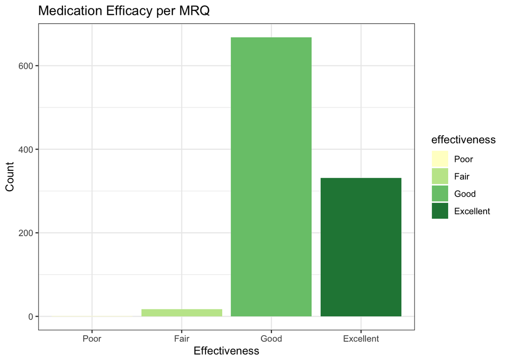

## 3.4 Adverse effects

### 3.4.1 Count of adverse effects

| Adverse effects by MRQ. | Adverse effects by MRQ. *N=1017* |
| --- | --- |
| adverse_effects |  |
| No | 0.99 (1011) |
| Yes | 0.01 ( 6) |

Numbers after proportions are frequencies.

### 3.4.2 Side effect details

| Side Effect Details |
| --- |
| flu-like symptoms - mild/moderate |
| Patient stated when taking the medication it feels like her face has a burning sensation |
| Hair loss. Provider aware. Patient will continue to take medication. No follow up needed. |
| flushing |
| patient has had a headache for approx. 1 week, she stated that she was going to reach out to her doctor and discuss |
| Dermatitis- she will be going to the doctor about the condition next week |

# 4 Pharmacist Interventions

## 4.1 Number of Interventions per Patient

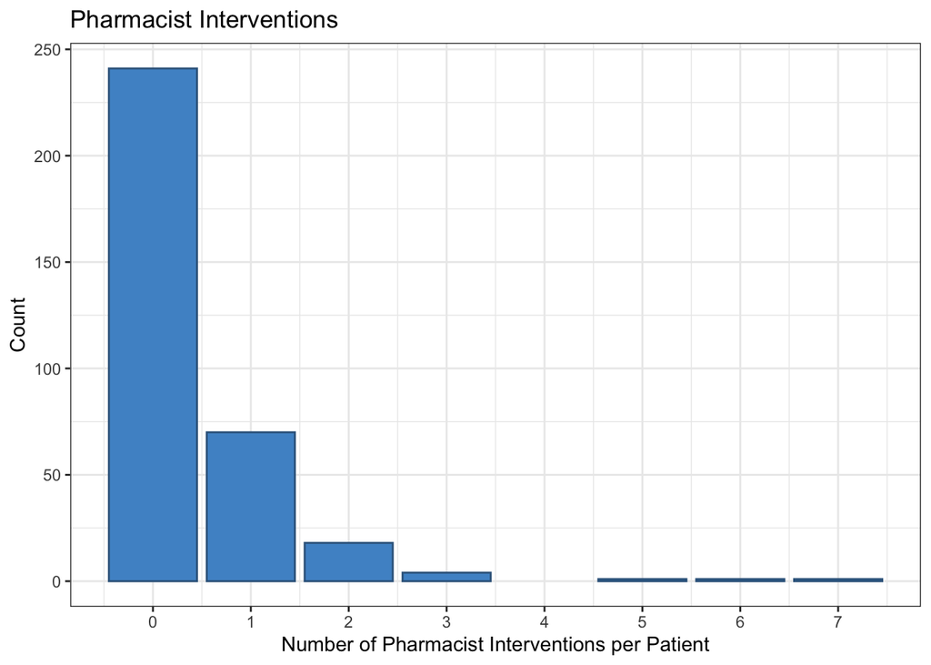

## 4.2 Types of Interventions

Total count of types of pharmacist interventions by intervention

| Interventions | Frequency |
| --- | --- |
| Adherence/Missed Dose | 39 |
| Therapeutic Monitoring - Safety | 36 |
| Common Side Effect/Toxicity | 20 |
| Other | 15 |
| Condition-Related Concern or Exacerbation | 13 |
| Coordination of Care | 11 |
| Financial/Insurance Issue | 9 |
| Medication List Change | 8 |
| ED/Hospitalization/Urgent Care Visit | 6 |
| New Condition or Diagnosis Identified | 6 |
| Medication Interaction | 5 |
| Adverse Event | 2 |
| Drug Administration Question | 2 |
| Drug Stability and Storage Question | 2 |
| Drug Dosing Question | 1 |

## 4.3 Outcomes of Interventions

Total count of outcomes of pharmacist interventions by intervention

| Interventions | Frequency |
| --- | --- |
| Identified Issue Resolved | 127 |
| Identified Issue Unresolved | 4 |
| Recommendation to Provider Accepted | 3 |
| Dosage Adjustment Made | 2 |
| Follow-Up Care Scheduled (Lab/Appointment) | 2 |
| Alternative Therapy Started | 1 |